# 白葡萄酒质量分析-Ivan

```r
knitr::opts_chunk$set(echo=FALSE, warning=FALSE, message=FALSE)
```

此报告包含近4900款白葡萄酒的评分及相关参数。

```
## [1] 4898   12
```

```
## 'data.frame':    4898 obs. of  12 variables:
##  $ fixed.acidity       : num  7 6.3 8.1 7.2 7.2 8.1 6.2 7 6.3 8.1 ...
##  $ volatile.acidity    : num  0.27 0.3 0.28 0.23 0.23 0.28 0.32 0.27 0.3 0.22 ...
##  $ citric.acid         : num  0.36 0.34 0.4 0.32 0.32 0.4 0.16 0.36 0.34 0.43 ...
##  $ residual.sugar      : num  20.7 1.6 6.9 8.5 8.5 6.9 7 20.7 1.6 1.5 ...
##  $ chlorides           : num  0.045 0.049 0.05 0.058 0.058 0.05 0.045 0.045 0.049 0.044 ...
##  $ free.sulfur.dioxide : num  45 14 30 47 47 30 30 45 14 28 ...
##  $ total.sulfur.dioxide: num  170 132 97 186 186 97 136 170 132 129 ...
##  $ density             : num  1.001 0.994 0.995 0.996 0.996 ...
##  $ pH                  : num  3 3.3 3.26 3.19 3.19 3.26 3.18 3 3.3 3.22 ...
##  $ sulphates           : num  0.45 0.49 0.44 0.4 0.4 0.44 0.47 0.45 0.49 0.45 ...
##  $ alcohol             : num  8.8 9.5 10.1 9.9 9.9 10.1 9.6 8.8 9.5 11 ...
##  $ quality             : int  6 6 6 6 6 6 6 6 6 6 ...
```

```
##  fixed.acidity    volatile.acidity  citric.acid     residual.sugar
##  Min.   : 3.800   Min.   :0.0800   Min.   :0.0000   Min.   : 0.600
##  1st Qu.: 6.300   1st Qu.:0.2100   1st Qu.:0.2700   1st Qu.: 1.700
##  Median : 6.800   Median :0.2600   Median :0.3200   Median : 5.200
##  Mean   : 6.855   Mean   :0.2782   Mean   :0.3342   Mean   : 6.391
##  3rd Qu.: 7.300   3rd Qu.:0.3200   3rd Qu.:0.3900   3rd Qu.: 9.900
##  Max.   :14.200   Max.   :1.1000   Max.   :1.6600   Max.   :65.800
##    chlorides       free.sulfur.dioxide total.sulfur.dioxide
##  Min.   :0.00900   Min.   :  2.00      Min.   :  9.0
##  1st Qu.:0.03600   1st Qu.: 23.00      1st Qu.:108.0
##  Median :0.04300   Median : 34.00      Median :134.0
##  Mean   :0.04577   Mean   : 35.31      Mean   :138.4
##  3rd Qu.:0.05000   3rd Qu.: 46.00      3rd Qu.:167.0
##  Max.   :0.34600   Max.   :289.00      Max.   :440.0
##     density             pH          sulphates         alcohol
##  Min.   :0.9871   Min.   :2.720   Min.   :0.2200   Min.   : 8.00
##  1st Qu.:0.9917   1st Qu.:3.090   1st Qu.:0.4100   1st Qu.: 9.50
##  Median :0.9937   Median :3.180   Median :0.4700   Median :10.40
##  Mean   :0.9940   Mean   :3.188   Mean   :0.4898   Mean   :10.51
##  3rd Qu.:0.9961   3rd Qu.:3.280   3rd Qu.:0.5500   3rd Qu.:11.40
##  Max.   :1.0390   Max.   :3.820   Max.   :1.0800   Max.   :14.20
##     quality
##  Min.   :3.000
##  1st Qu.:5.000
##  Median :6.000
##  Mean   :5.878
##  3rd Qu.:6.000
##  Max.   :9.000
```

数据集有12个变量，最后一个是评分。观察11个参数变量：

# 单变量绘图选择

查看评分的分布情况：

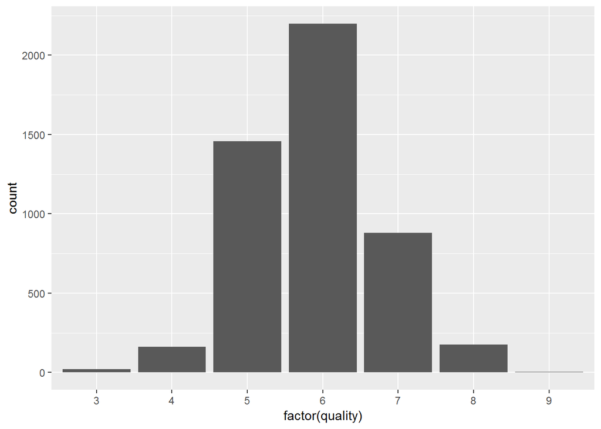

一大半的白葡萄酒评分在中间值5或者6，总体呈正态分布。

查看固定酸度的分布情况：

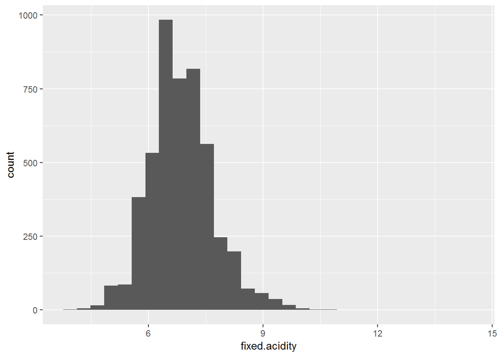

呈现长尾分布，对其做对数转换：

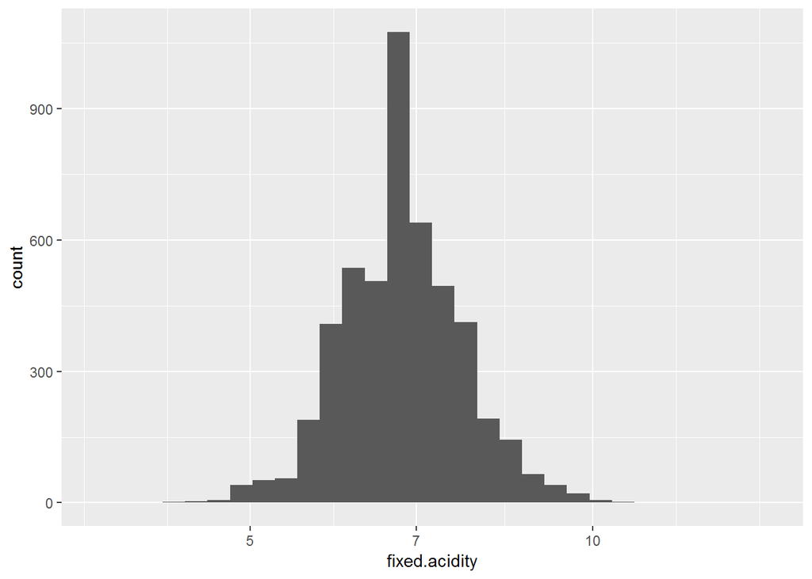

转换长尾数据后，看到固定酸度大部分在6和8之间。

查看挥发性酸度分布情况：

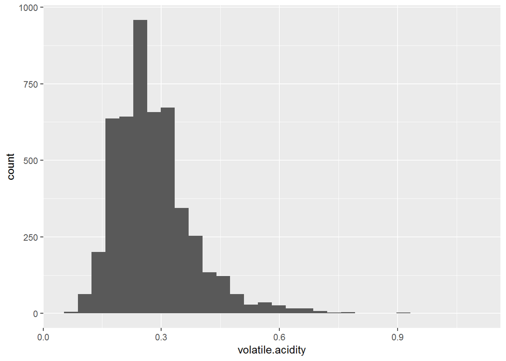

呈现长尾分布，对其做对数转换：

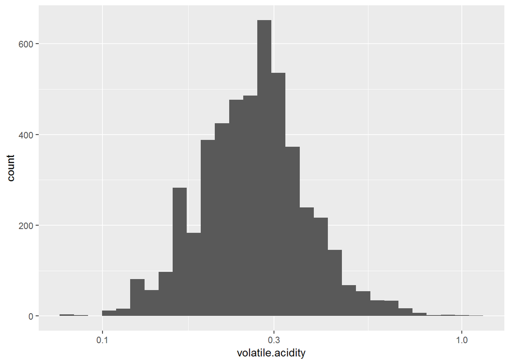

查看柠檬酸分布情况：

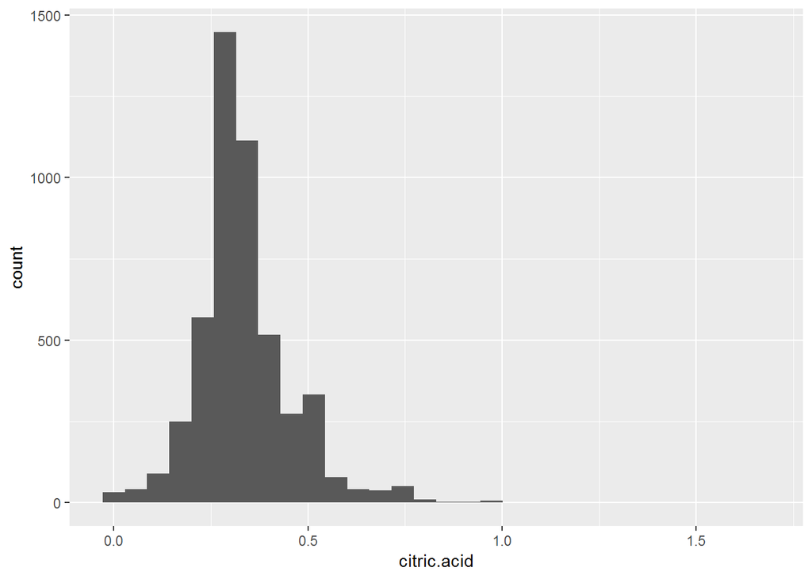

呈现长尾分布，对其做对数转换：

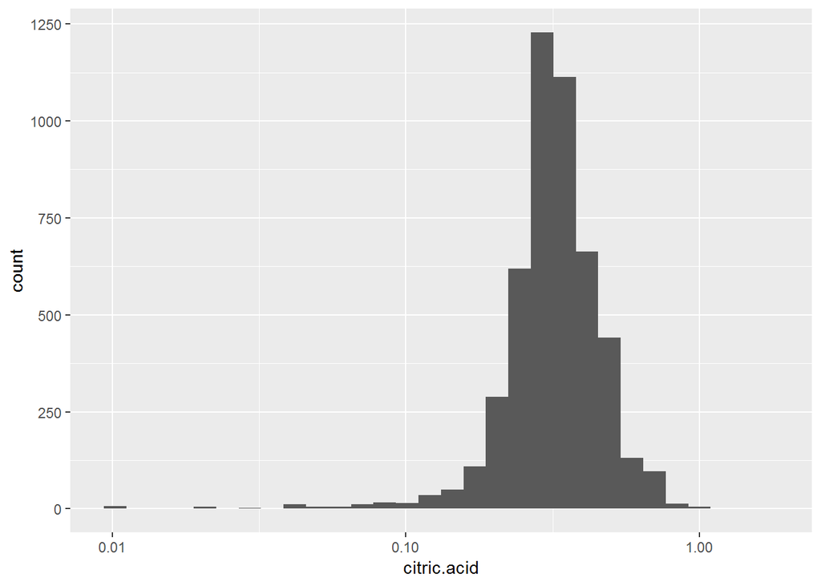

对数转换出现无限值，看到大部分柠檬酸在0.25和0.4之间。

查看残糖分布情况：

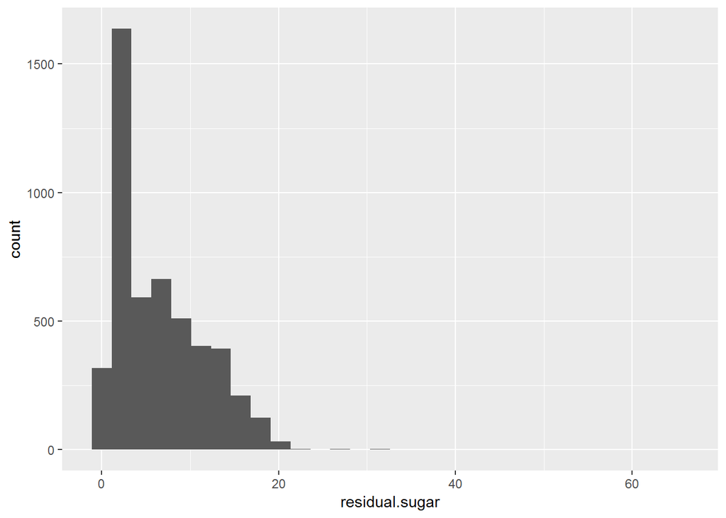

呈现长尾分布，对其做对数转换：

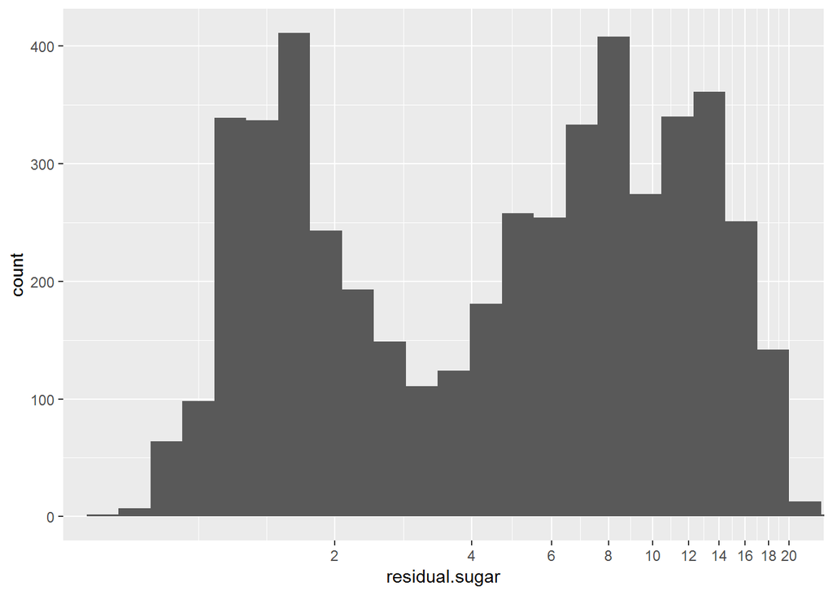

对数转换后出现双峰，看上去1.5和8.5两种残糖度数出现的比较多。

查看氯化物分布情况：

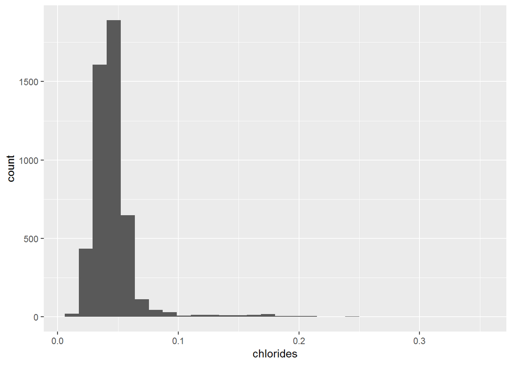

呈现长尾分布，对其做对数转换：

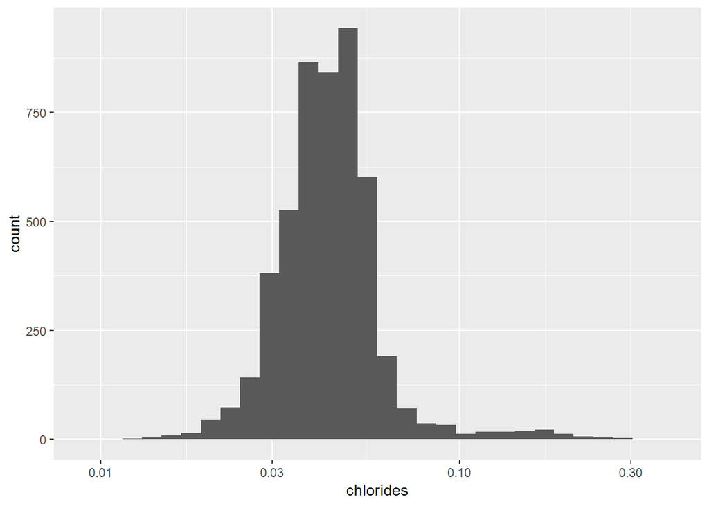

可以看到，大部分氯化物值出现在0.05左右。

查看游离二氧化硫分布情况：

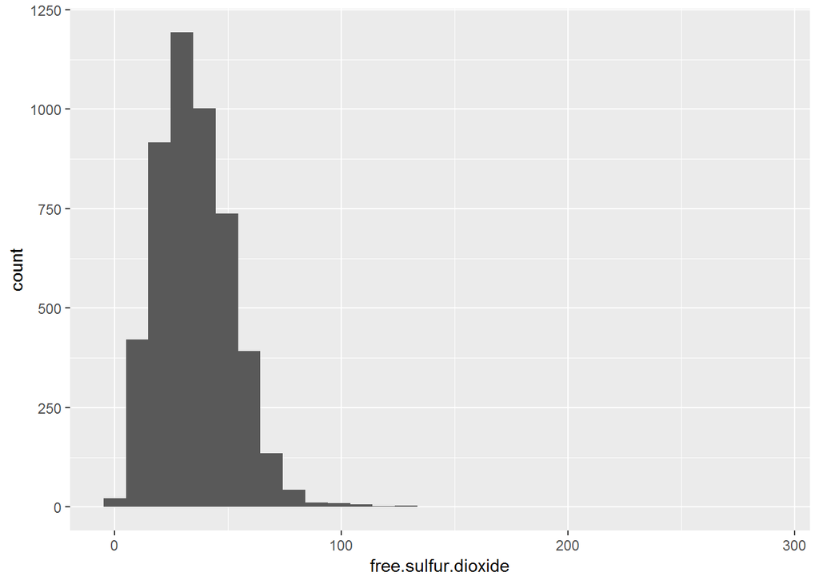

呈现长尾分布，对其做对数转换：

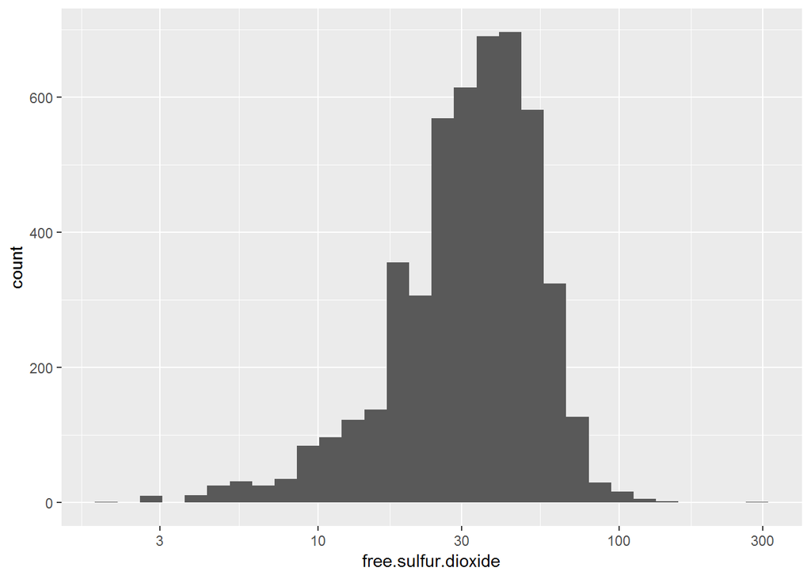

可以看到，游离二氧化硫出现最多的值在40左右。

查看总二氧化硫分布情况：

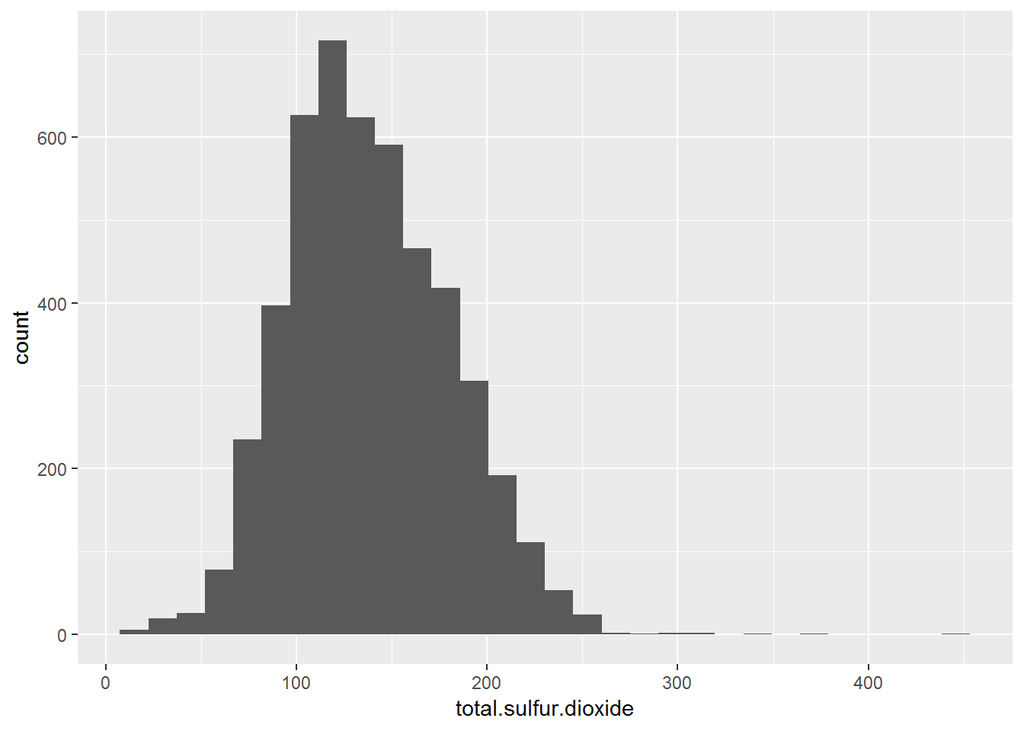

呈现长尾分布，对其做对数转换：

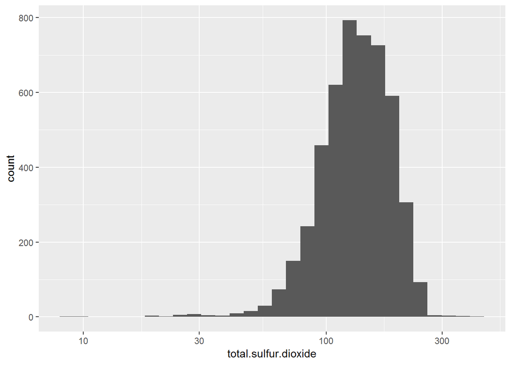

查看密度分布情况：

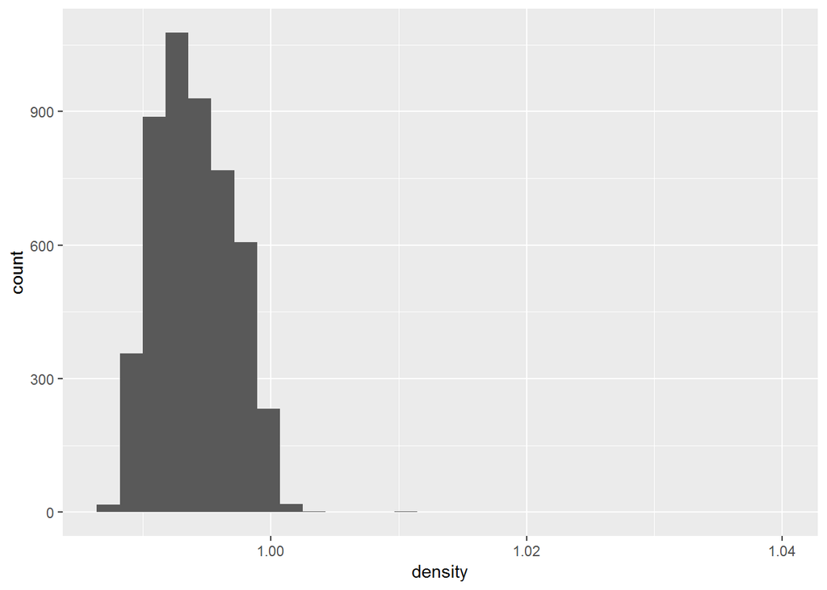

删除密度的最高0.1%的异常值：

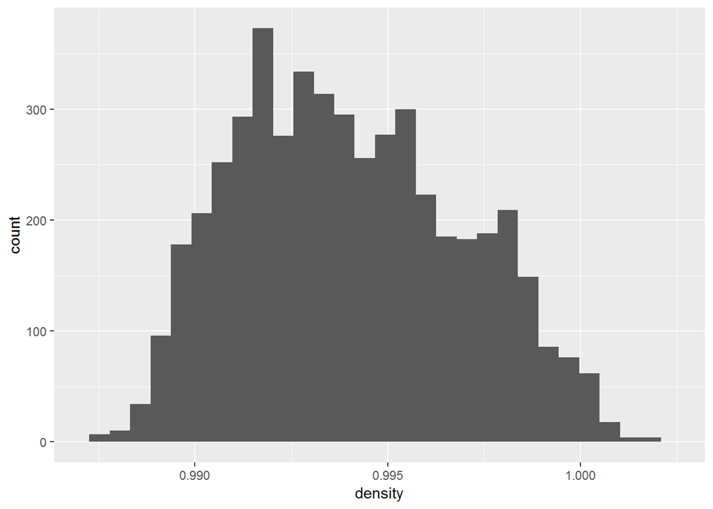

大部分密度在0.990到0.997之间。

由于“在游离SO2浓度超过50 ppm时，SO2在葡萄酒的气味和味道中变得明显”，这里我对游离SO2的ppm值产生了兴趣。因为游离SO2的单位是0.001 kg / m3， 而密度的单位是1000 kg / m3， 所以游离SO2的ppm值应该是游离SO2值乘以1000000再除以密度，即定义变量so2_ppm = free.sulfur.dioxide / density.

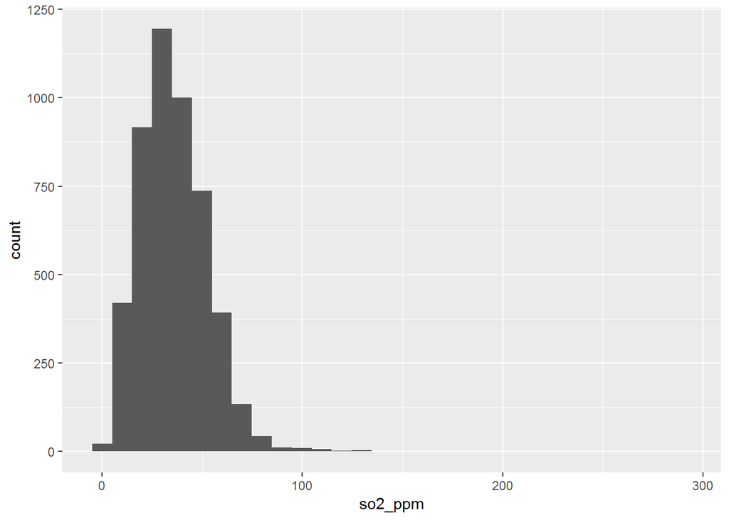

呈现长尾分布，对其做对数转换，并集中观察10到80之间的分布：

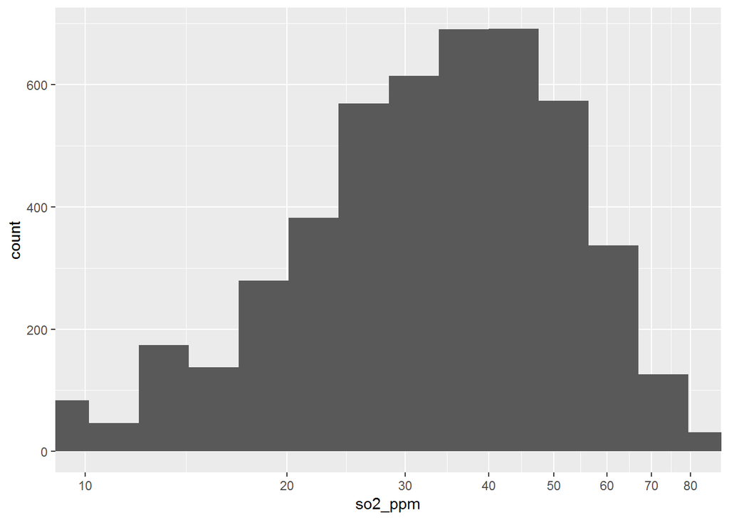

so2_ppm值在40左右最多，超过50下降明显。

查看PH值分布情况：

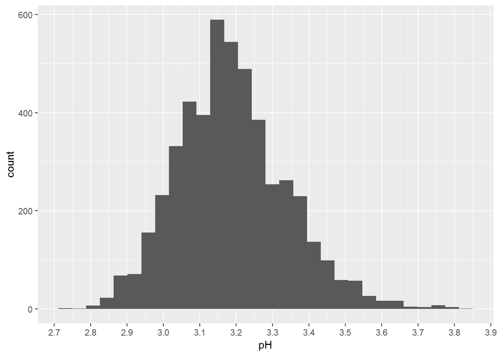

```
##    Min. 1st Qu.  Median    Mean 3rd Qu.    Max.
##   2.720   3.090   3.180   3.188   3.280   3.820
```

pH值均值3.188，中位数3.180.

查看硫酸盐分布情况：

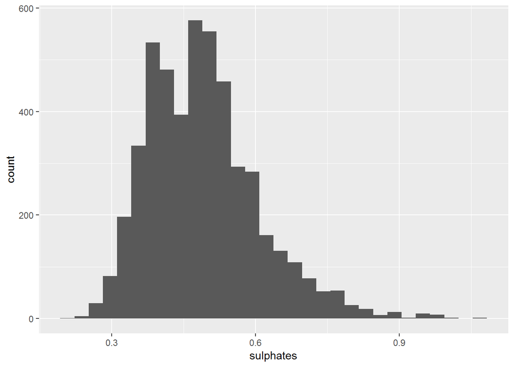

呈现长尾分布，对其做对数转换：

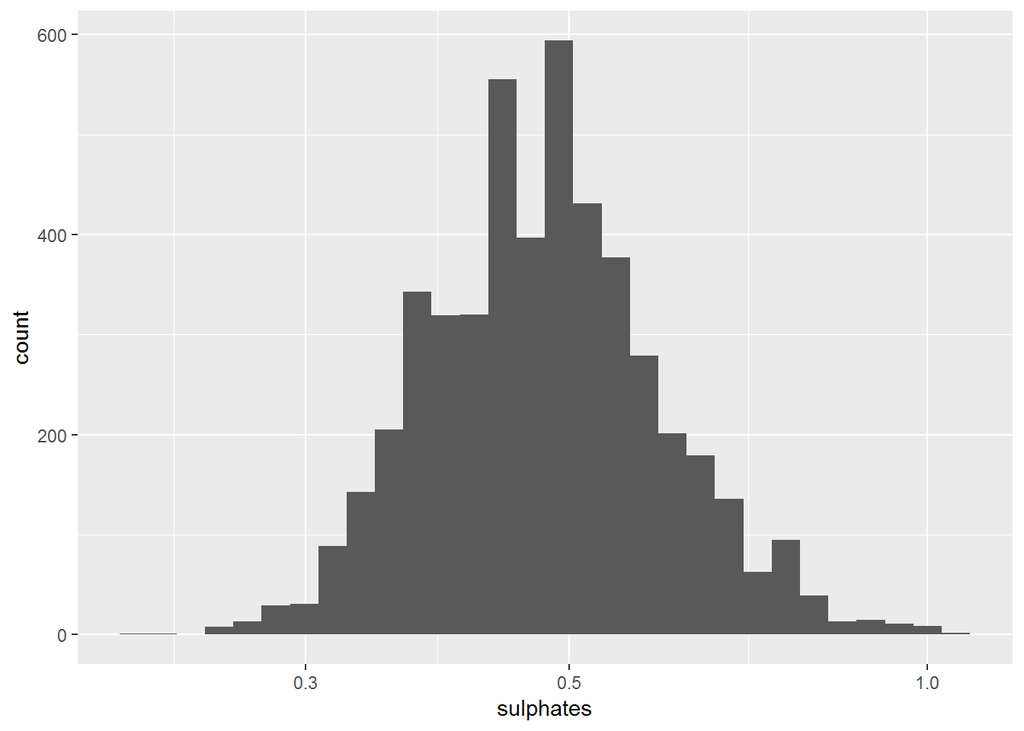

硫酸盐能够促进so2含量，我感觉这个变量应该和so2含量相关性很强。

查看酒精度分布情况：

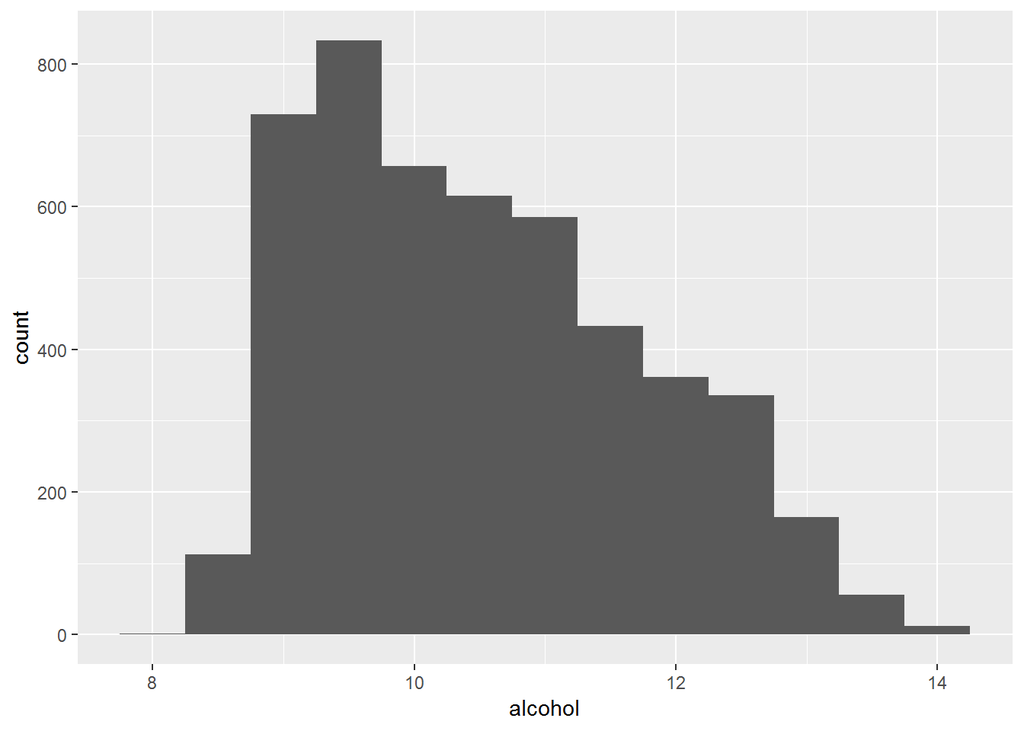

观察酒精度的值频数：

```
##
##              9.4              9.5              9.2                9
##              229              228              199              185
##               10             10.5               11             10.4
##              162              160              158              153
##              9.1              9.8             10.8              9.3
##              144              136              135              134
##             10.2              9.6             11.4             10.1
##              130              128              121              114
##             10.6             11.2              9.9              8.8
##              114              112              109              107
##              9.7               12             11.3             10.7
##              105              102              101               96
##              8.9             10.9             11.5             12.2
##               95               88               88               86
##             10.3             11.1             12.5              8.7
##               85               83               83               78
##             12.4             12.6             12.3             11.8
##               68               63               62               60
##             11.7             12.7             12.8             11.9
##               58               56               54               53
##             12.1             11.6             12.9               13
##               51               46               39               36
##              8.6             13.4             13.1             13.2
##               23               20               18               14
##             13.5              8.5             13.6             13.3
##               12                9                9                7
##             13.7               14            11.45              8.4
##                7                5                4                3
## 9.53333333333333            10.15 10.9666666666667 11.3333333333333
##                3                3                3                3
##            12.75             13.9                8             9.55
##                3                3                2                2
## 9.73333333333333 10.1333333333333 10.4666666666667            10.55
##                2                2                2                2
## 10.9333333333333            11.05 11.6333333333333            11.75
##                2                2                2                2
##            11.94            12.15 12.8933333333333             13.8
##                2                2                2                2
## 9.63333333333333             9.75 10.0333333333333 10.5333333333333
##                1                1                1                1
## 10.5666666666667            10.65            10.98 11.0666666666667
##                1                1                1                1
## 11.2666666666667            11.35 11.3666666666667 11.4333333333333
##                1                1                1                1
## 11.4666666666667            11.55            11.65 11.7333333333333
##                1                1                1                1
##            11.85            11.95            12.05 12.0666666666667
##                1                1                1                1
##            12.25 12.3333333333333            13.05 13.1333333333333
##                1                1                1                1
##            13.55            14.05             14.2
##                1                1                1
```

改变binwidth可以更加明显地看出，基于感官的数据总体反映了酒精度最多出现在9到10之间，随后随数值增加数量减少。

# 单变量分析

### 你的数据集内感兴趣的主要特性有哪些？

游离二氧化硫，总二氧化硫和硫酸盐这几个特性应该是强相关的；残糖呈现双峰分布，值得研究。

### 你认为数据集内哪些其他特征可以帮助你探索兴趣特点？

固定酸度，挥发性酸度，柠檬酸，氯化物和酒精度都能够帮助我建立更加精确的模型，预测酒的评分。

### 根据数据集内已有变量，你是否创建了任何新变量？

是的，我创建了so2的ppm值这一变量，用于研究这个值在50上下的分布情况。

### 在已经探究的特性中，是否存在任何异常分布？你是否对数据进行一些操作，如清洁、调整或改变数据的形式？如果是，你为什么会这样做？

# 双变量绘图选择

查看各参数之间相关系数：

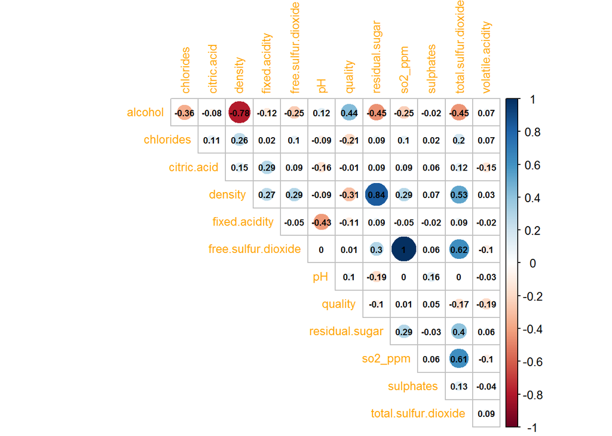

可以看出，评分与所有的参数都没有强相关关系，与酒精度和密度存在一定相关关系；与此同时，参数之间的相关性较为丰富：密度和残糖之间强相关，密度和酒精度强相关，在第一部分猜测的总二氧化硫和游离二氧化硫之间的相关性一般，总二氧化硫和密度的相关性也一般。

查看酒精度和评分关系：

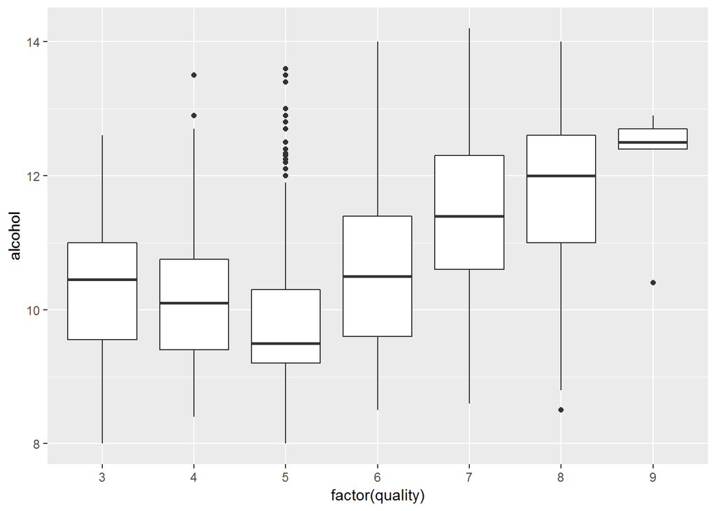

酒精度和评分存在一定相关关系，但不明显。

查看密度和评分关系：

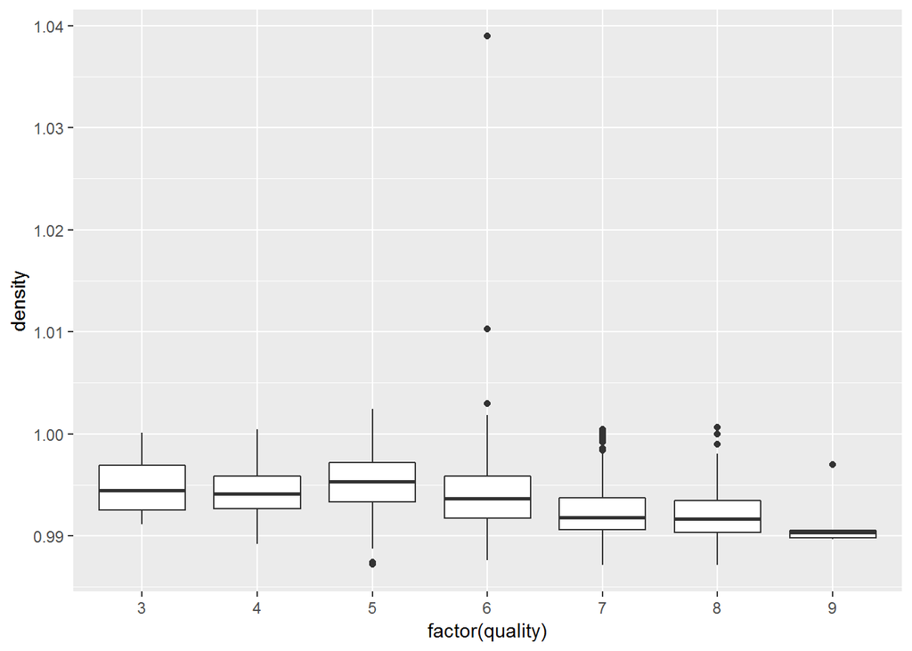

去除密度最高的0.1%异常值：

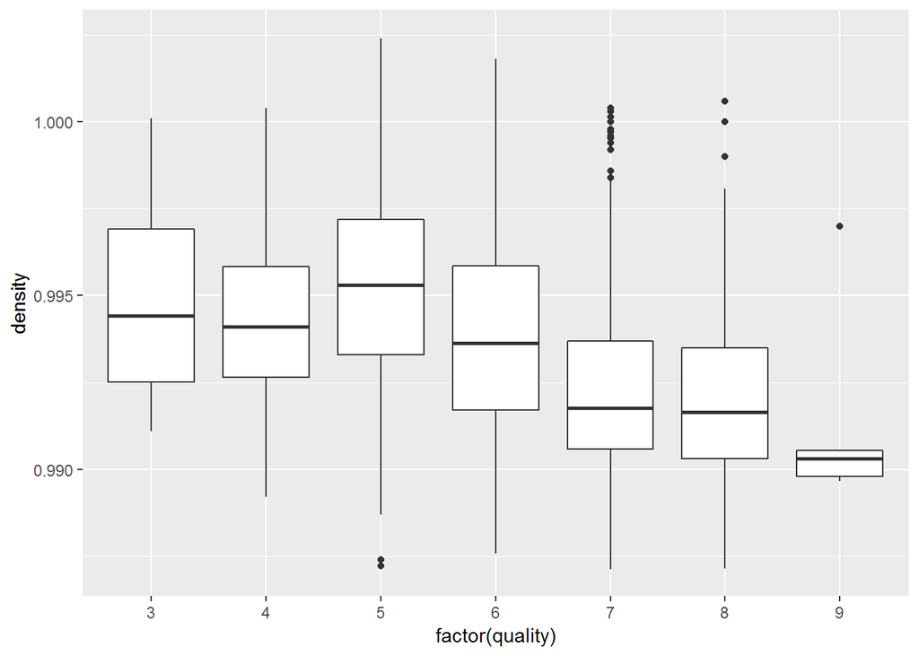

密度和评分存在一定相关关系，但不明显。

查看密度和残糖关系：

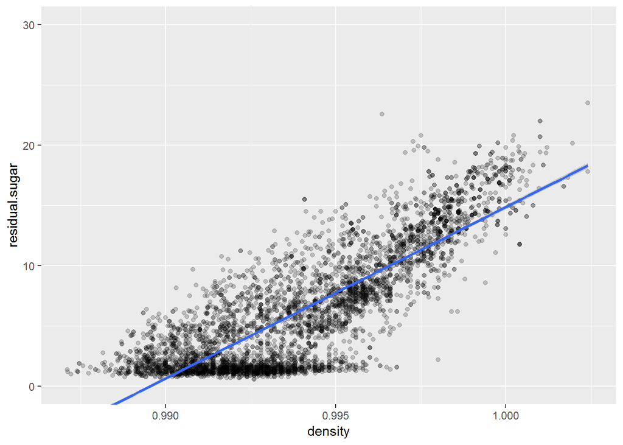

呈现一定的正相关关系。

查看密度和酒精度关系：

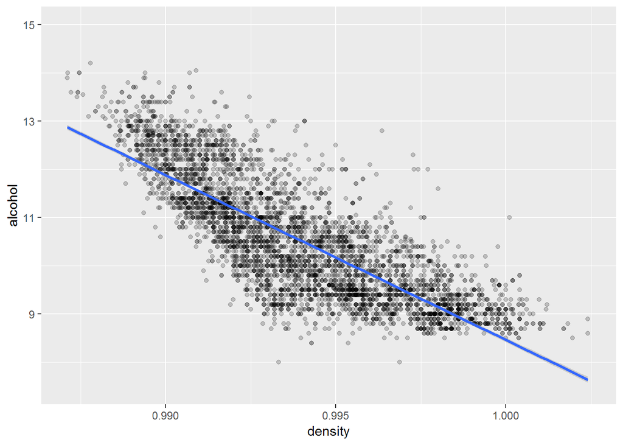

呈现一定的负相关关系。

# 双变量分析

### 探讨你在这部分探究中观察到的一些关系。这些感兴趣的特性与数据集内其他特性有什么区别？

评分与所有的参数都没有强相关关系，与酒精度和密度存在一定相关关系，但不明显。

### 你是否观察到主要特性与其他特性之间的有趣关系？

密度和酒精度存在较强的负相关关系，这与我的直觉一致，因为酒精比水轻；  
密度和残糖之间存在较强的正相关关系，这与我的直觉一致；  
二氧化硫的ppm值与游离二氧化硫完全相关，因为ppm是游离二氧化硫的线性表达。

### 你发现最强的关系是什么？

是密度和残糖的正相关关系。在预测评分时这两个变量应该二选一。